# Conecticut State Government Salaries EDA - Week 6 by Kyle Maher

### Setup

**Packages**

```r
library(tidyverse)

# Relative File Pathing
library(this.path)

# Clean table outputs
library(gt)

# Includes Yeo Johnson Transformation
library(car)

# Shape File Manipulation
library(sf)
library(tigris)
options(tigris_use_cache = TRUE)

# Clean Log Scaling
library(scales)

# Plot Output Manipulaiton
library(patchwork)

# Gender from First Name
library(gender)

# Linear Model output to table
library(broom)

# Reprodicibility
set.seed(280)
```

# Data Selection

## Fact Table

### Filter

- Full/Part = “F”
- Term Date is Null

### Group By

- First Name
- Middle Initial
- Last Name
- Name Suffix
- Orig Hire
- Pyrl Fiscal Yr

### Aggregate By

- Sum Tot Gross
- Sum Salaries & Wages
- Sum Overtime

## Dimension Table

### Filter

- Full/Part = “F”
- Term Date is Null

### Group By

- First Name
- Middle Initial
- Last Name
- Name Suffix
- Orig Hire
- Pyrl Fiscal Yr
- Job Cd Desc
- City
- Zip
- Agency
- Department

# Data Re-construction

## Left join Dimension Table to Fact Table on

- First Name
- Middle Initial
- Last Name
- Name Suffix
- Orig Hire
- Pyrl Fiscal Yr

## R Loading Process

- Changed column names
- Changed data types
- Stored as a R Data Save (.rds)

**load_salary_data.r**

```r
library(tidyverse)
library(this.path)

df_fact <- read_csv(file.path(
  dirname(this.path()),
  "..",
  "data",
  "filtered_download",
  "pay_by_name_columns_and_hire_date.csv"
))

df_dim <- read_csv(file.path(
  dirname(this.path()),
  "..",
  "data",
  "filtered_download",
  "job_city_zip_agency_department_by_name_columns_and_hire_date.csv"
))

rows_prior <- nrow(df_dim)
df_dim <- df_dim %>%
  distinct(`First Name`,
           `Middle Initial`,
           `Last Name`,
           `Name Suffix`,
           `Orig Hire`,
           `Pyrl Fiscal Yr`,
           .keep_all = TRUE)
rows_after <- nrow(df_dim)
print(paste("Removed", rows_prior - rows_after, "rows to account for
             employees with multiple parameters for the same year."))

df <- df_fact %>%
  left_join(df_dim, by = c(
    "First Name",
    "Middle Initial",
    "Last Name",
    "Name Suffix",
    "Orig Hire",
    "Pyrl Fiscal Yr"
  ))

df <- df %>%
  group_by(
    `First Name`,
    `Middle Initial`,
    `Last Name`,
    `Name Suffix`,
    `Orig Hire`
  ) %>%
  mutate(employee_id = cur_group_id()) %>%
  ungroup()

df <- df %>%
  select(
    -`Middle Initial`,
    -`Name Suffix`
  )

df <- df %>%
  rename(
    year = "Pyrl Fiscal Yr",
    first_name = "First Name",
    last_name = "Last Name",
    gross_pay = "Tot Gross",
    overtime = "Overtime",
    salary = "Salaries & Wages",
    hire_date = "Orig Hire",
    job = "Job Cd Descr",
    city = "City",
    zip = "Postal",
    # union = "Union Descr",
    agency = "Agency",
    department = "Department"
  )

df <- df %>%
  mutate(
    year = as.numeric(year),
    first_name = as.character(first_name),
    last_name = as.character(last_name),
    gross_pay = as.numeric(gross_pay),
    overtime = as.numeric(overtime),
    salary = as.numeric(salary),
    hire_date = as.Date(hire_date, format = "%m/%d/%Y %I:%M:%S %p"),
    job = as.factor(job),
    city = as.factor(city),
    zip = as.factor(zip),
    agency = as.factor(agency),
    department = as.factor(department)
  )

saveRDS(df, file.path(
  dirname(this.path()),
  "..",
  "data",
  "clean",
  "annual_salary_data.rds"
))
```

## R Cleaning Process

**clean_salary_data.r**

```r
library(tidyverse)
library(this.path)


df <- readRDS(file.path(
  dirname(this.path()),
  "..",
  "data",
  "clean",
  "annual_salary_data.rds"
))


### Remove rows with undisclosed first and last name
rows_to_drop <- df %>%
  filter(first_name == "Undisclosed", last_name == "Undisclosed") %>%
  nrow()
df <- df %>%
  filter(first_name != "Undisclosed", last_name != "Undisclosed")
print(paste("Dropped", rows_to_drop, "due undisclosed name."))


### Remove rows with negative overtime, salary, and gross
rows_to_drop <- df %>%
  filter(overtime < 0 | salary < 0 | gross_pay < 0) %>%
  nrow()
df <- df %>%
  filter(overtime >= 0, salary >= 0, gross_pay >= 0)
print(paste("Dropped", rows_to_drop, "due to negative pay."))

### Remove rows for individuals hired in 1900
rows_to_drop <- df %>%
  filter(hire_date == "1901-01-01") %>%
  nrow()
df <- df %>%
  filter(hire_date != "1901-01-01")
print(paste("Dropped", rows_to_drop, "due to invalid hire date.
Note many are likely due to a join based on hire date."))

### Adjust hire date for individuals with a hire date after their first pay year
df <- df %>%
  group_by(employee_id) %>%
  mutate(first_year = min(year)) %>%
  ungroup() %>%
  mutate(
    hire_date = if_else(
      as.numeric(difftime(as.Date(paste0(year, "-07-01")), hire_date, "days")) < 0,
      as.Date(paste0(first_year, "-01-01")),
      hire_date
    ),
    years_since_hired = time_length(
      interval(hire_date, as.Date(paste0(year, "-07-01"))),
      "years"
    )
  ) %>%
  select(-first_year)

### Account for Capitalized City Names
df <- df %>%
  mutate(city = str_to_title(city)) %>%
  mutate(agency = str_to_title(agency)) %>%
  mutate(city = as.factor(city)) %>%
  mutate(agency = as.factor(agency))

### Remove Zipcode Extension
df <- df %>%
  mutate(zip = as.character(zip), zip = substr(zip, 1, 5))

### Add name
df <- df %>%
  mutate(name = paste(first_name, last_name))

saveRDS(df, file.path(
  dirname(this.path()),
  "..",
  "data",
  "clean",
  "annual_salary_data.rds"
))
```

## Load Cleaned Data

**Read .rds File**

```r
df <- readRDS(file.path(
  dirname(this.path()),
  "..",
  "data",
  "clean",
  "annual_salary_data.rds"
))
```

# Summary Information

### Employees by Year

**Distinct Employees by Year**

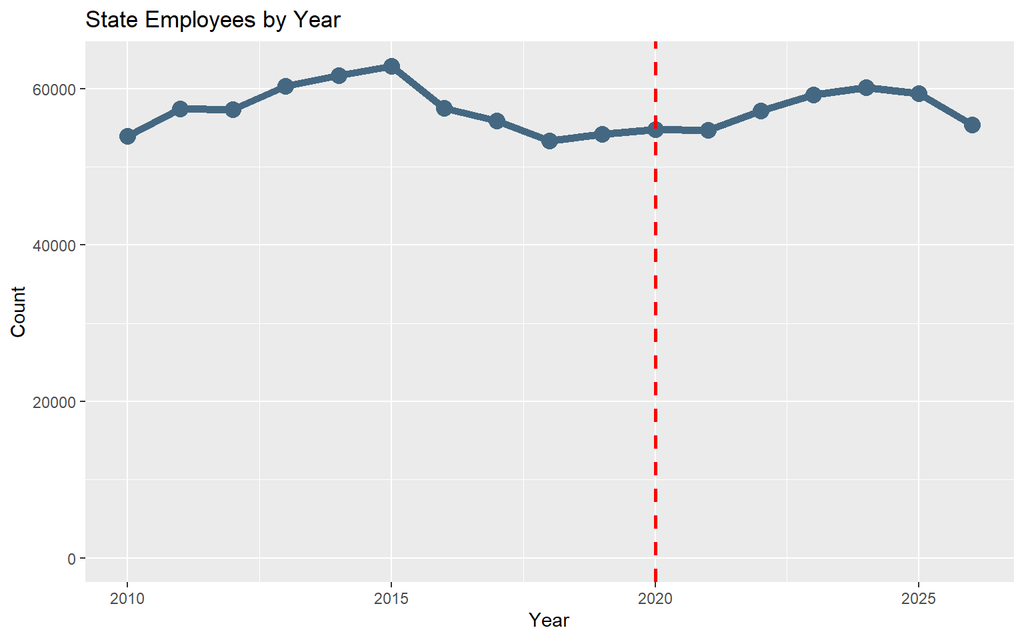

```r
df %>%
  group_by(year) %>%
  summarise(count = n_distinct(employee_id)) %>%
  ggplot(aes(x = year, y = count)) +
  geom_line(color = "#456882", linewidth = 2) +
  geom_point(color = "#456882", size = 4) +
  labs(
    x = "Year",
    y = "Count",
    title = "State Employees by Year"
  ) +
  expand_limits(y = 0) +
  geom_vline(xintercept = 2020, color = "red", linetype = "dashed", linewidth = 1)
```

# Adjust for Inflaiton

Account for inflation using the consumer price index with 2024 as the base year.

**CPI Adjustment**

```r
yearly_cpi <- data.frame(
  year = 2010:2024,
  cpi = c(218.1, 224.9, 229.6, 233.0, 236.7, 237.0, 240.0,
          245.1, 251.1, 255.7, 258.8, 271.0, 292.7, 304.7,
          313.7)
)

df <- df %>%
  left_join(yearly_cpi, by = "year") %>%
  mutate(adj_annual_rate = gross_pay * (313.7 / cpi)) %>%
  select(-cpi)

rows_to_drop <- df %>%
  filter(year > 2024) %>%
  nrow()
df <- df %>%
  filter(year <= 2024)
print(paste("Dropped rows", rows_to_drop, "with a year after 2024."))
```

```
[1] "Dropped rows 114729 with a year after 2024."
```

[CPI Data from the Bureau of Labor Statistics](https://www.bls.gov/cpi/tables/supplemental-files/) File Name: Historical CPI-U, August 2025 (XLSX)

# Top Paid Employees

### Top 15 by Salary

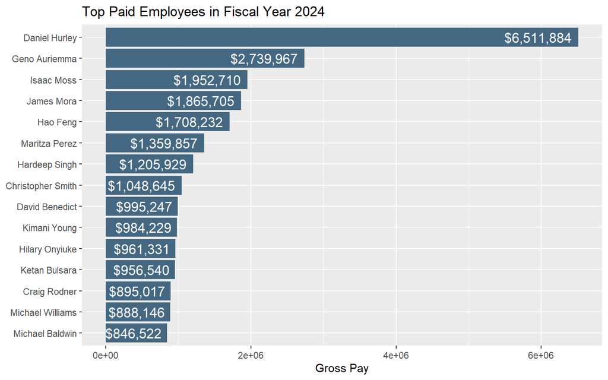

```r
df %>%
  filter(year == 2024) %>%
  group_by(name) %>%
  summarize(total_pay = sum(gross_pay, na.rm = TRUE), .groups = "drop") %>%
  slice_max(total_pay, n = 15) %>%
  ggplot(aes(x = total_pay, y = reorder(name, total_pay))) +
  geom_col(fill = "#456882") +
  labs(
    title = "Top Paid Employees in Fiscal Year 2024",
    x = "Gross Pay",
    y = NULL
  ) +
  geom_text(
    aes(label = paste0("$", scales::comma(round(total_pay)))),
    hjust = 1.1,
    size = 4.5,
    color = "white"
  )
```

### Comparing with payroll.com

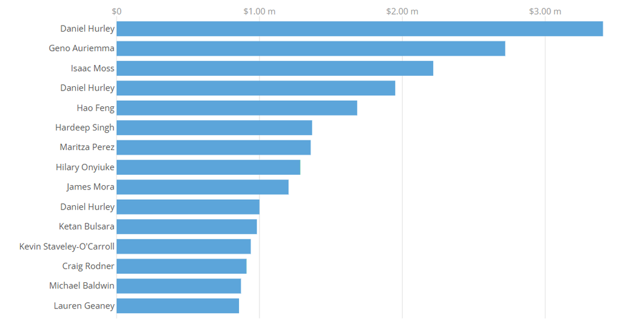

```r
knitr::include_graphics(file.path(
  dirname(this.path()),
  "..",
  "images",
  "open_payroll_top_paid_2024.png"
))
```

# Adding Gender

### Used IQR for Hire Date to Judge Name Window

```r
summary(df$hire_date)
```

```
        Min.      1st Qu.       Median         Mean      3rd Qu.         Max.
"1954-12-16" "1996-11-18" "2006-01-20" "2004-04-30" "2012-11-02" "2024-06-13"
```

Note the package could only go as recent as 2012.

**Use Gender Package**

```r
names <- df %>%
  distinct(first_name) %>%
  pull(first_name)

gender_output <- gender(names, method = "ssa", years = c(1998, 2012))

gender_by_name <- gender_output %>%
  # filter(proportion_male < .4 | proportion_male > .6) %>%
  group_by(name) %>%
  slice_max(year_max, n = 1, with_ties = FALSE) %>%
  ungroup() %>%
  select(name, gender)

df <- df %>%
  left_join(gender_by_name, by = c("first_name" = "name"))

rows_to_remove <- df %>%
  filter(is.na(gender)) %>%
  nrow()
df <- df %>%
  filter(!is.na(gender))
print(paste("Removed", rows_to_remove, "rows where gender could not be determined."))
```

```
[1] "Removed 58085 rows where gender could not be determined."
```

# Goal

- Are there groups that had atypical wage changes around 2020?

### Add Percent Change

**Calculate Percent Change**

```r
df <- df %>%
  filter(!is.na(adj_annual_rate))

df <- df %>%
  arrange(employee_id, year) %>%
  group_by(employee_id) %>%
  mutate(adj_annual_rate_pct_change =
           if_else(
             !is.na(lag(adj_annual_rate)) & lag(adj_annual_rate) != 0,
             (adj_annual_rate - lag(adj_annual_rate)) / lag(adj_annual_rate) * 100,
             NA_real_
           )) %>%
  ungroup()

breaks  <- c(-100, -10, 0, 10, 100, Inf)
labels  <- c("- 100%-10%", "- 10%-0%", "0%-10%", "10%-100%", "100%+")

df <- df %>%
  mutate(adj_annual_rate_pct_change_bin = cut(
    adj_annual_rate_pct_change,
    breaks = breaks,
    labels = labels,
    include.lowest = TRUE,
    right = FALSE
  ))

df <- df %>%
  filter(!is.na(adj_annual_rate_pct_change))
```

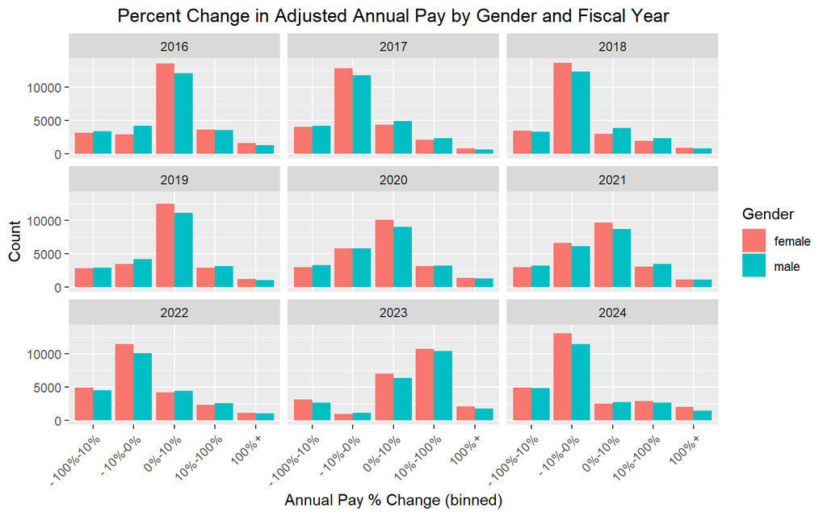

```r
df %>%
  filter(year >= 2016) %>%
  ggplot(aes(x = adj_annual_rate_pct_change_bin, fill = gender)) +
  geom_bar(position = "dodge") +
  facet_wrap(~year) +
  labs(
    x = "Annual Pay % Change (binned)",
    y = "Count",
    title = "Percent Change in Adjusted Annual Pay by Gender and Fiscal Year",
    fill = "Gender"
  ) +
  theme(
    axis.text.x = element_text(angle = 45, hjust = 1),
    plot.title = element_text(hjust = 0.5)
  )
```

### Filter for Top Agencies

```r
top_agencies <- df %>%
  filter(year == 2024) %>%
  count(agency, name = "Count") %>%
  arrange(desc(Count)) %>%
  filter(Count >= 500) %>%
  pull(agency)

df_filtered <- df %>%
  filter(agency %in% top_agencies)
```

### Filter for Top Jobs

```r
top_jobs <- df %>%
  filter(year == 2024) %>%
  count(job, name = "Count") %>%
  arrange(desc(Count)) %>%
  filter(Count >= 500) %>%
  pull(job)

df_filtered <- df_filtered %>%
  filter(job %in% top_jobs)
```

### Basic Linear Model

```r
result <- lm(
  adj_annual_rate_pct_change ~
  gender +
  job +
  agency +
  years_since_hired,
  data = df_filtered %>%
    filter(year == 2020)
  )
tidy(result) %>%
  filter(p.value < .05) %>%
  gt() %>%
  tab_header("Basic Regression Checking for Factors")
```

Basic Regression Checking for Factors

| term | estimate | std.error | statistic | p.value |
| --- | --- | --- | --- | --- |
| (Intercept) | 61.113972 | 9.2831560 | 6.583318 | 4.814075e-11 |
| jobJudicialEmployee | 37.416723 | 10.1365959 | 3.691251 | 2.242520e-04 |
| jobSW-Socl&HumanSvcs | 50.044644 | 11.3235130 | 4.419533 | 9.987923e-06 |
| jobUCHC Faculty | 33.368921 | 13.5438066 | 2.463777 | 1.376363e-02 |
| jobUCHC UniversityHealthProf | 29.771844 | 10.2044646 | 2.917531 | 3.535415e-03 |
| years_since_hired | -5.383279 | 0.2841827 | -18.943021 | 9.469145e-79 |

### Checking for Multiplicative Relationships

```r
result <- lm(
  adj_annual_rate_pct_change ~
  gender *
  job *
  agency *
  years_since_hired,
  data = df_filtered %>%
    filter(year == 2020)
  )
tidy(result) %>%
  filter(p.value < .05) %>%
  gt() %>%
  tab_header(
    title = "Multiplicative Regression Checking for Factors"
  )
```

Multiplicative Regression Checking for Factors

| term | estimate | std.error | statistic | p.value |
| --- | --- | --- | --- | --- |
| (Intercept) | 53.875334 | 16.630815 | 3.239489 | 0.001201075 |
| jobJudicialEmployee | 57.733975 | 22.431246 | 2.573819 | 0.010071523 |
| jobSW-Socl&HumanSvcs | 53.698379 | 21.885946 | 2.453555 | 0.014160903 |
| gendermale:jobJudicialEmployee | 93.776593 | 32.399483 | 2.894386 | 0.003806641 |
| jobJudicialEmployee:years_since_hired | -4.457784 | 2.220008 | -2.008003 | 0.044667851 |
| gendermale:jobJudicialEmployee:years_since_hired | -6.218944 | 3.093761 | -2.010156 | 0.044439530 |

# Investigation Based on Regression Outputs

### Judicial Employees

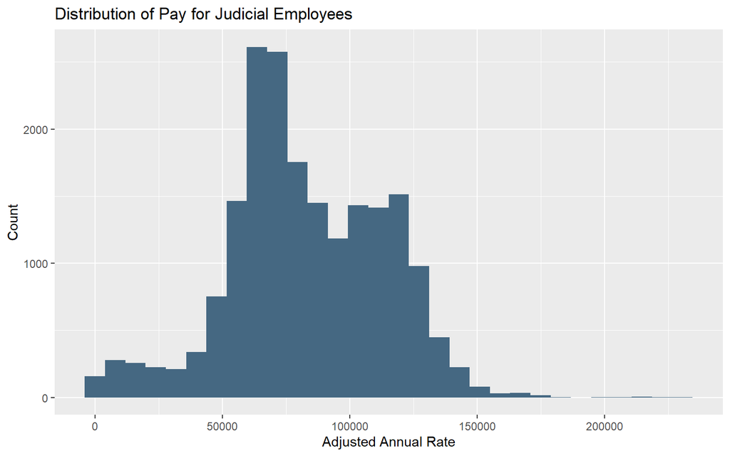

```r
df %>%
  filter(job == "JudicialEmployee") %>%
  filter(year >= 2016) %>%
  ggplot(aes(x = adj_annual_rate)) +
  geom_histogram(fill = "#456882", bins = 30) +
  labs(
    x = "Adjusted Annual Rate",
    y = "Count",
    title = "Distribution of Pay for Judicial Employees"
  )
```

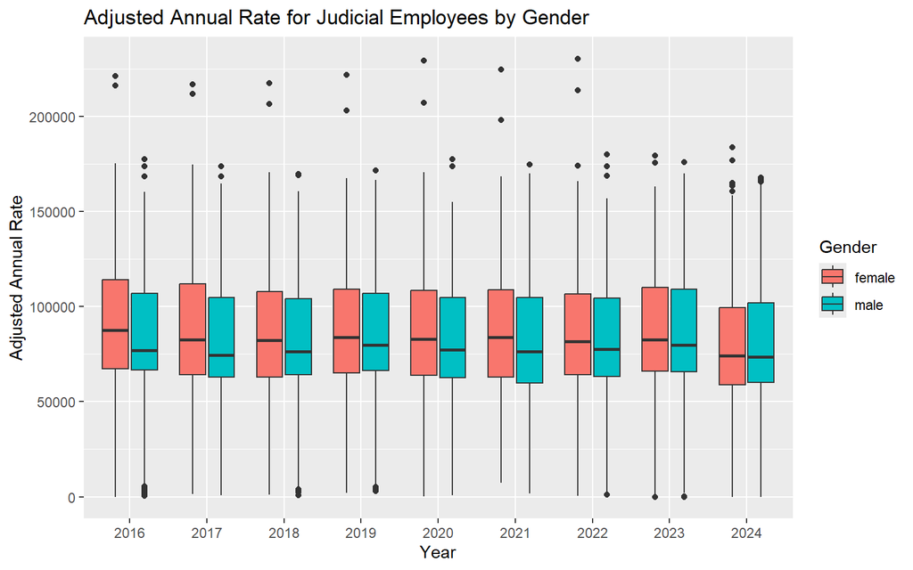

```r
df %>%
  filter(job == "JudicialEmployee") %>%
  filter(year >= 2016) %>%
  ggplot(aes(x = as.factor(year), y = adj_annual_rate, fill = gender)) +
  geom_boxplot() +
  labs(
    x = "Year",
    y = "Adjusted Annual Rate",
    title = "Adjusted Annual Rate for Judicial Employees by Gender",
    fill = "Gender"
  )
```

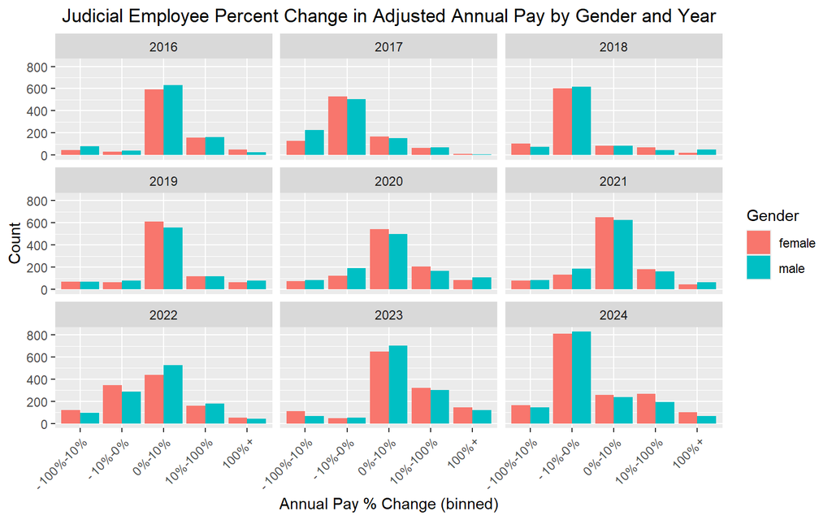

```r
df %>%
  filter(job == "JudicialEmployee") %>%
  filter(year >= 2016) %>%
  ggplot(aes(x = adj_annual_rate_pct_change_bin, fill = gender)) +
  geom_bar(position = "dodge") +
  facet_wrap(~year) +
  labs(
    x = "Annual Pay % Change (binned)",
    y = "Count",
    title = "Judicial Employee Percent Change in Adjusted Annual Pay by Gender and Year",
    fill = "Gender"
  ) +
  theme(
    axis.text.x = element_text(angle = 45, hjust = 1),
    plot.title = element_text(hjust = 0.5)
  )
```

### Judicial Employees by Agency & Department

```r
df %>%
  filter(job == "JudicialEmployee") %>%
  count(agency) %>%
  gt()
```

| agency | n |
| --- | --- |
| Judicial Branch | 29108 |
| Probate Court Administration | 166 |

```r
df %>%
  filter(job == "JudicialEmployee") %>%
  count(department) %>%
  gt()
```

| department | n |
| --- | --- |
| Judicial Branch | 2919 |
| Probate Court Administration | 19 |
| NA | 26336 |

```r
df %>%
  filter(job == "JudicialEmployee") %>%
  count(city) %>%
  gt()
```

| city | n |
| --- | --- |
| Hartford | 29274 |

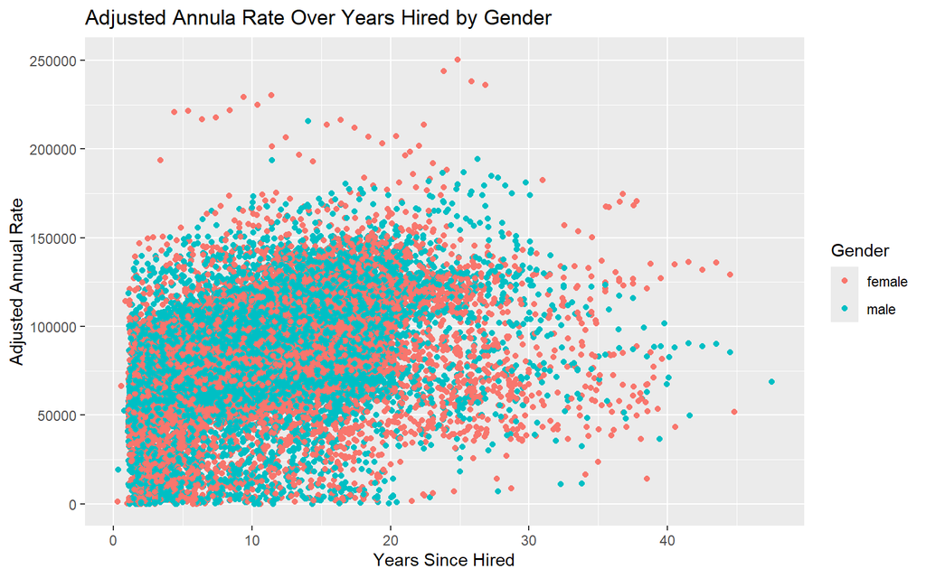

```r
df %>%
  filter(job == "JudicialEmployee") %>%
  ggplot(aes(x = years_since_hired, y = adj_annual_rate, color = gender)) +
  geom_point() +
  labs(
    x = "Years Since Hired",
    y = "Adjusted Annual Rate",
    title = "Adjusted Annula Rate Over Years Hired by Gender",
    color = "Gender"
  )
```

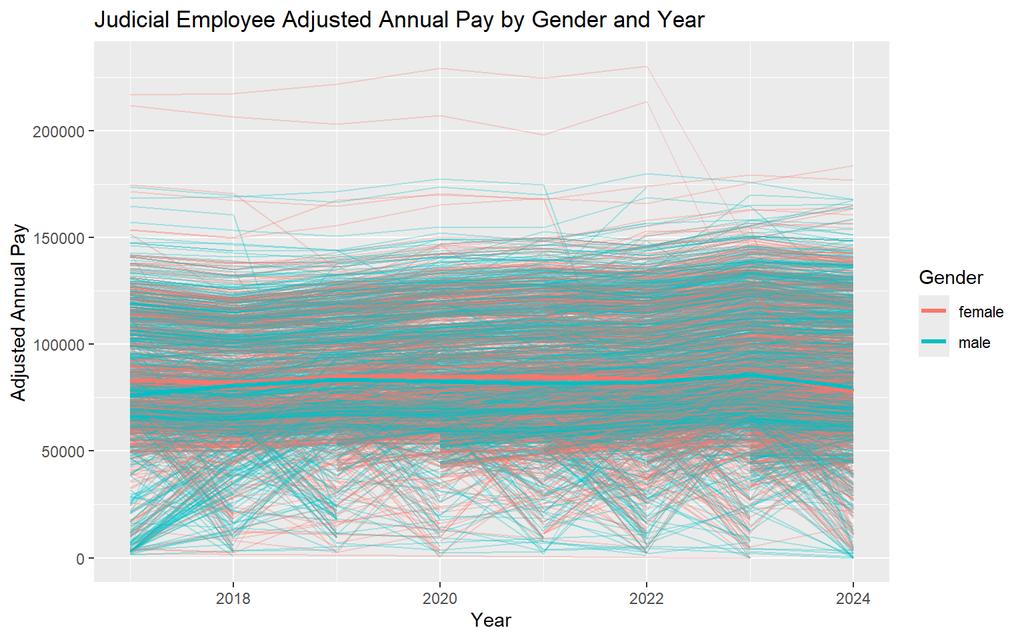

```r
jud_avg <- df_filtered %>%
  filter(year > 2016, job == "JudicialEmployee") %>%
  group_by(year, gender) %>%
  summarise(mean_pay = mean(adj_annual_rate, na.rm = TRUE), .groups = "drop")

df_filtered %>%
  filter(year > 2016, job == "JudicialEmployee") %>%
  ggplot(aes(x = year, y = adj_annual_rate, color = gender)) +
  geom_line(aes(group = employee_id), alpha = 0.3) +
  geom_line(data = jud_avg, aes(x = year, y = mean_pay, color = gender), linewidth = 1.2) +
  labs(
    x = "Year",
    y = "Adjusted Annual Pay",
    title = "Judicial Employee Adjusted Annual Pay by Gender and Year",
    color = "Gender"
  )
```

# Transportation Management

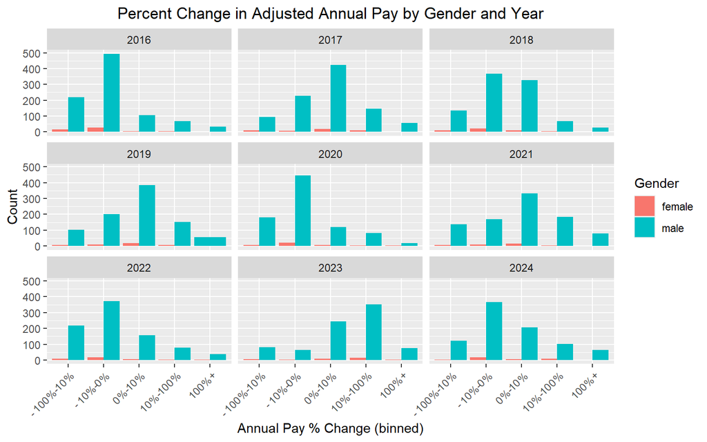

```r
df %>%
  count(job) %>%
  arrange(desc(n)) %>%
  head(1000) %>%
  View()

df %>%
  filter(str_detect(job, "TranspMntr")) %>%
  filter(year >= 2016) %>%
  ggplot(aes(x = adj_annual_rate_pct_change_bin, fill = gender)) +
  geom_bar(position = "dodge") +
  facet_wrap(~year) +
  labs(
    x = "Annual Pay % Change (binned)",
    y = "Count",
    title = "Percent Change in Adjusted Annual Pay by Gender and Year",
    fill = "Gender"
  ) +
  theme(
    axis.text.x = element_text(angle = 45, hjust = 1),
    plot.title = element_text(hjust = 0.5)
  )
```

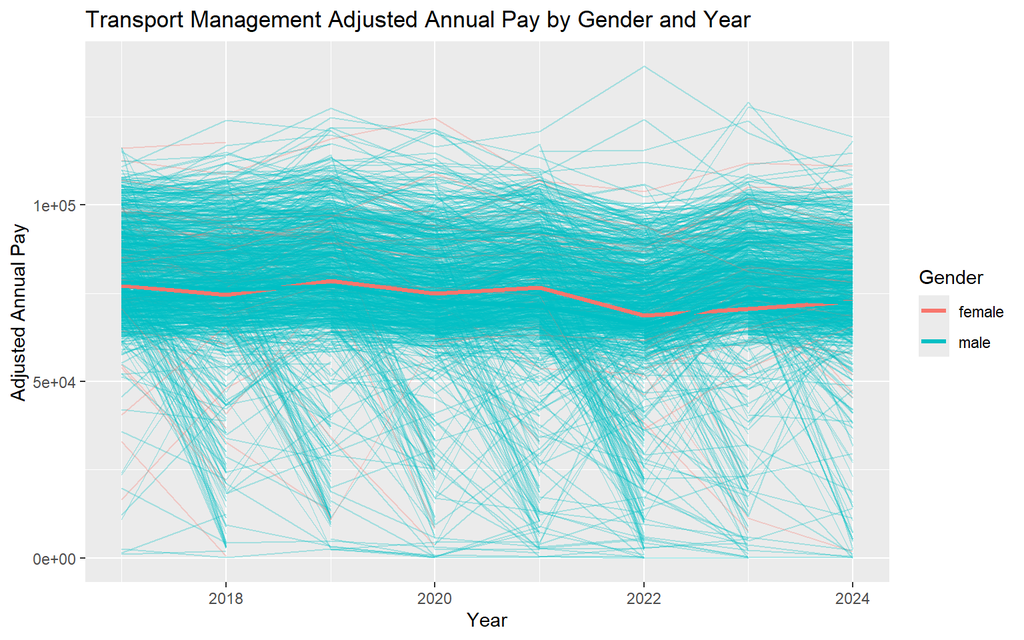

```r
df_avg <- df %>%
  filter(str_detect(job, "TranspMntr")) %>%
  filter(year > 2016) %>%
  group_by(year, gender) %>%
  summarise(mean_pay = mean(adj_annual_rate, na.rm = TRUE), .groups = "drop")

df %>%
  filter(str_detect(job, "TranspMntr")) %>%
  filter(year > 2016) %>%
  ggplot(aes(x = year, y = adj_annual_rate, color = gender)) +
  geom_line(aes(group = employee_id), alpha = 0.3) +
  geom_line(data = df_avg, aes(x = year, y = mean_pay, color = gender), size = 1.2) +
  labs(
    x = "Year",
    y = "Adjusted Annual Pay",
    title = "Transport Management Adjusted Annual Pay by Gender and Year",
    color = "Gender"
  )
```

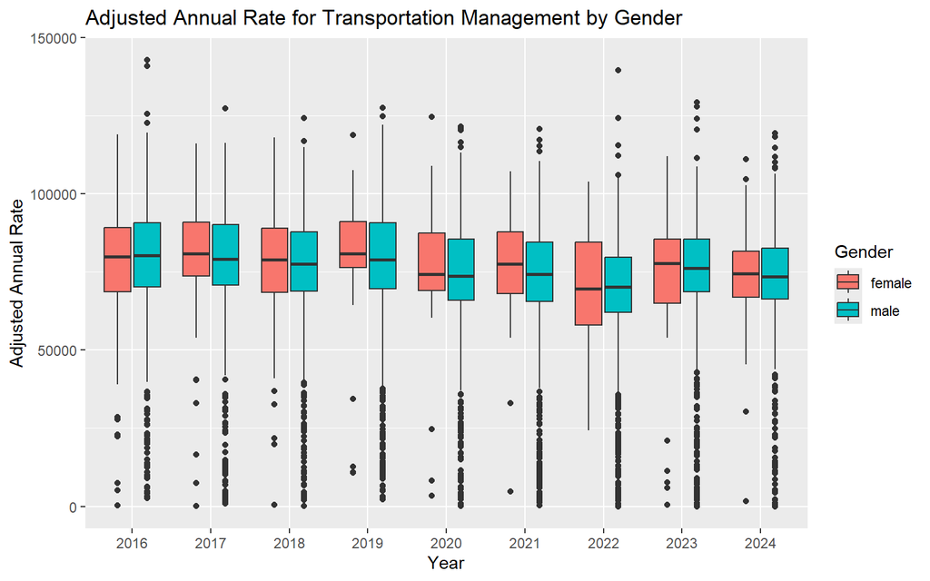

```r
df %>%
  filter(str_detect(job, "TranspMntr")) %>%
  filter(year >= 2016) %>%
  ggplot(aes(x = as.factor(year), y = adj_annual_rate, fill = gender)) +
  geom_boxplot() +
  labs(
    x = "Year",
    y = "Adjusted Annual Rate",
    title = "Adjusted Annual Rate for Transportation Management by Gender",
    fill = "Gender"
  )
```

# Conclusions

Regression led to investigation of Judicial Employees which didn’t show the effect anticipated. A hunch that Transportation wages would be negatively affected durring Covid years did result in some preliminary findings that support that idea.